# data science for the ocean health index

ben best <bbest@nceas.ucsb.edu>  
2014-04-15 in santa barbara, ca

### overview

1. ocean health index
2. data flow
3. data wrangling
4. distributed development

### what is a healthy ocean?

- pristine?

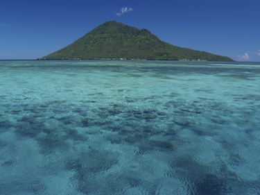

- “a healthy ocean *sustainably* delivers a range of *benefits* to **people** *now* and in the *future*”
- quantify using publicly available datasets (*mostly*)
- halpern et al. (2012) *nature*.
- rolling out toolbox for individual countries to formulate own index
- “reproducible research”

### what do we measure?

### goals

1. natural products
2. food provision
3. artisanal fishing
4. carbon storage
5. coastal protection
6. tourism & recreation
7. livelihoods & economies
8. sense of place
9. biodiversity
10. clean waters

### process

- set a reference point
- index = avg(status, future)
- future ~ status, trend, resilience (+), pressures (-)
- pressure = matrix of weights, goals vs pressures
- resilience = matrix of weights, goals vs resilience

### overview

1. ocean health index
2. **data flow**
3. data wrangling
4. distributed development

### flow

- darren hardy (https://github.com/drh-stanford)
- [**linear-flow**](https://github.com/drh-stanford/linear-flow): *swiss-army knife for scientific workflows*
- linux file server with ssd, postgresql
- data/
  - raw/ -> ingest/ -> stable/ -> model/
    - [study area]-[provider]-[product]_[version]/  
      eg “GL-WorldBank-Statistics_v2012/”
      - manual_output/, tmp/ -> data/
      - scripts.*: setup, download, import, ingest, model, run, digest, export, report, upload, finish
      - *.languages: sh, py, r, sql, pl, rb

### flow: install & run

```bash
python setup.py install
cd example
flow
```

```
Running flow [rootdir=~/linear-flow-master/example] depth=0 nproc=1

Running package with default style [~/linear-flow-master/example]

Running python script import.py
Generating some dummy data in data.csv...

Running R script model.R
Running R script model.r
```

### flow: principles

- extract, transform, load (etl)
- makefile
- common output format: data/*.**csv**

### overview

1. ocean health index
2. data flow
3. **data wrangling**
4. distributed development

### data wrangling

- **task**: calculate the batting average (AVG): number of base hits (H) divided by the total number of at bats (AB) using the Lahman baseball database. limit to Babe Ruth and Jackie Robinson.
- setup

```r
library(Lahman)
library(dplyr)
library(RSQLite)
```

- result

```
  nameFirst nameLast    avg
      Babe      Ruth  0.323
    Jackie  Robinson  0.308
```

### data wrangling: sql

- **sql** ([**csv2psql**](https://github.com/drh-stanford/csv2psql))

```r
tbl(lahman_sqlite(), sql(
"SELECT nameFirst, nameLast,
  ROUND(AVG(H/(AB*1.0)), 3) AS avg
FROM Batting
JOIN Master USING (playerID)
WHERE AB > 0 AND ((
  (nameFirst = 'Babe' AND
   nameLast = 'Ruth') OR
  (nameFirst = 'Jackie' AND
   nameLast = 'Robinson'))
GROUP BY nameFirst, nameLast
ORDER BY avg DESC")))
```

### data wrangling: dplyr

- chaining (`%.%`): grammar of data manipulation

```r
Batting %.%
  merge(Master, by='playerID') %.%
  filter(
    AB > 0 &
    (nameFirst=='Babe' &
     nameLast =='Ruth') |
    (nameFirst=='Jackie' &
     nameLast =='Robinson')) %.%
  group_by(nameFirst, nameLast) %.%
  summarise(avg = round(mean(H/AB), 3)) %.%
  arrange(desc(avg))
```

### overview

1. ocean health index
2. data flow
3. data wrangling
4. **distributed development**

### distributed dev: fork & pull

| direction | org web | user web | user local |
| --- | --- | --- | --- |
|  | `github.com/[org]/[repo]` | `github.com/[user]/[repo]` | `~/github/[repo]` |
| -> (1x) |  | -> [fork](https://help.github.com/articles/fork-a-repo) | -> [clone](https://help.github.com/articles/fetching-a-remote) |
| <- | [merge](https://help.github.com/articles/merging-a-pull-request) {admin} <- | <- [pull request](https://help.github.com/articles/creating-a-pull-request) | <- [push](https://github.com/OHI-Science/ohiprep/wiki/Setup#rstudio), <-> [commit](https://github.com/OHI-Science/ohiprep/wiki/Setup#rstudio) |

where:

- `[org]` is an organization (eg `ohi-science`)
- `[repo]` is a repository in the orgranization (eg `ohiprep`)
- `[user]` is your github username (eg `bbest`)

### github features

- track changes, issues, etc. free for public repos
- max: 1GB per repo, 100MB per file. so larger files (and binary) on file server, with remote vpn option
- render markdown, eg README.md
- [csv view](https://github.com/OHI-Science/ohiprep/wiki/Software-Features#csv-view)
- [geojson view](https://github.com/OHI-Science/ohiprep/wiki/Software-Features#geographic-data-view)

## for more...

- ohi-science.org
  - ohiprep: data layer preparation
  - ohicore: r library of core functions
  - ohigui: graphical user interface with shiny and rCharts
- github.com/bbest / bbest.github.com / talks
  - [this talk](http://bbest.github.io/talks/2014-04-03_R-productivity), as [r presentation](http://bbest.github.io/talks/2014-04-03_R-productivity/index.Rpres)
  - [productivity with rstudio](http://bbest.github.io/talks/2014-04-03_R-productivity/): 1. data wrangling with dplyr, 2. documenting with markdown, 3. versioning with github
- other
  - [marwick reproducible research](http://benmarwick.github.io/CSSS-Primer-Reproducible-Research)
  - [github.com/datasets](http://data.okfn.org/roadmap/core-datasets)